# Chapter 2: Regression and model validation

```r
library(data.table)

# Read in learning2014 created with create_learning2014.R
learning2014<-fread("learning2014.txt")
```

## Dimensions and variable characteristics of learning2014

```r
# Number of records and number of variables in the dataset
dim(learning2014)
```

```
## [1] 166   7
```

```r
# Variable types (integers are integer variables, numerical are continuous floating number variables)
str(learning2014)
```

```
## Classes 'data.table' and 'data.frame':   166 obs. of  7 variables:
##  $ Gender  : int  2 1 2 1 1 2 1 2 1 2 ...
##  $ Age     : int  53 55 49 53 49 38 50 37 37 42 ...
##  $ Attitude: int  37 31 25 35 37 38 35 29 38 21 ...
##  $ Deep    : num  3.58 2.92 3.5 3.5 3.67 ...
##  $ Stra    : num  3.38 2.75 3.62 3.12 3.62 ...
##  $ Surf    : num  2.58 3.17 2.25 2.25 2.83 ...
##  $ Points  : int  25 12 24 10 22 21 21 31 24 26 ...
##  - attr(*, ".internal.selfref")=<externalptr>
```

Gender: Male = 1, Female = 2  
Age: Age (in years) derived from the date of birth  
Attitude: Global attitude toward statistics  
Deep: Deep approach  
Stra: Strategic approach  
Surf: Surface approach  
Points: Yhteispisteet (max kaikista)

### Variable summary statistics

```r
summary(learning2014)
```

```
##      Gender           Age           Attitude          Deep
##  Min.   :1.000   Min.   :17.00   Min.   :14.00   Min.   :1.583
##  1st Qu.:1.000   1st Qu.:21.00   1st Qu.:26.00   1st Qu.:3.333
##  Median :2.000   Median :22.00   Median :32.00   Median :3.667
##  Mean   :1.663   Mean   :25.51   Mean   :31.43   Mean   :3.680
##  3rd Qu.:2.000   3rd Qu.:27.00   3rd Qu.:37.00   3rd Qu.:4.083
##  Max.   :2.000   Max.   :55.00   Max.   :50.00   Max.   :4.917
##       Stra            Surf           Points
##  Min.   :1.250   Min.   :1.583   Min.   : 7.00
##  1st Qu.:2.625   1st Qu.:2.417   1st Qu.:19.00
##  Median :3.188   Median :2.833   Median :23.00
##  Mean   :3.121   Mean   :2.787   Mean   :22.72
##  3rd Qu.:3.625   3rd Qu.:3.167   3rd Qu.:27.75
##  Max.   :5.000   Max.   :4.333   Max.   :33.00
```

### Histograms of variables to visualize distribution shapes

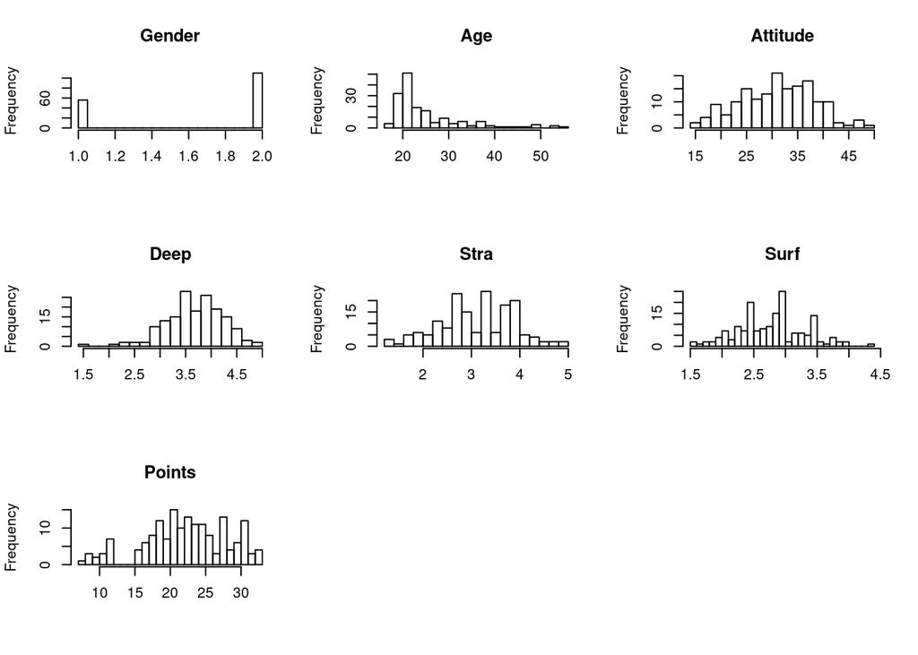

```r
par(mfrow=c(3,3))
sapply(1:ncol(learning2014),function(i) hist(learning2014[[i]], breaks=20, xlab=NA,main=names(learning2014)[i]))
```

### Density plots

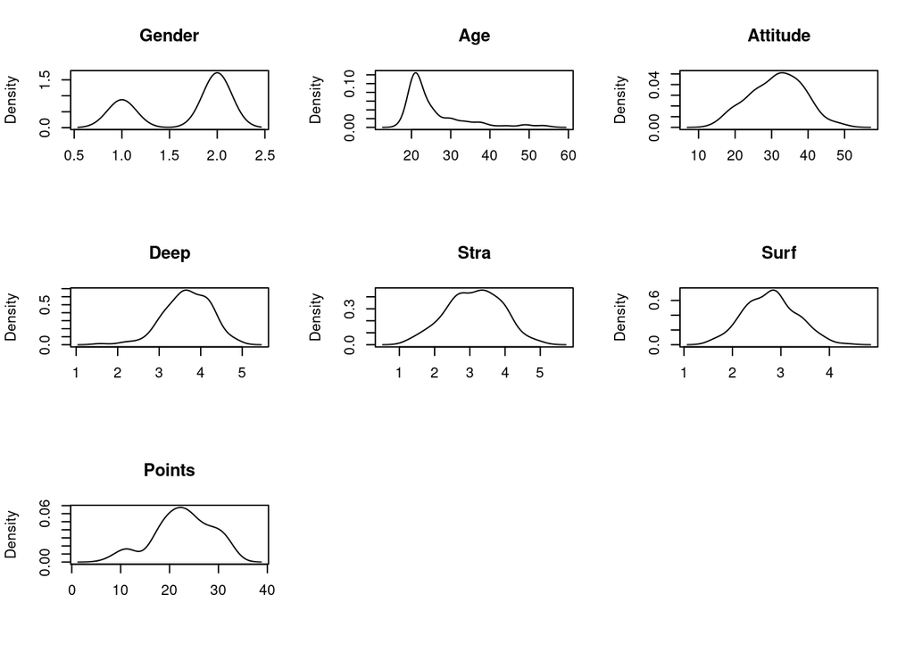

```r
par(mfrow=c(3,3))
sapply(1:ncol(learning2014),function(i) plot(density(learning2014[[i]]), xlab=NA,main=names(learning2014)[i]))
```

Age has a long right tail. Attitude, Deep, Stra, and Surf could be considered approximately normally distributed. From Surf and Stra histograms we can clearly see that they are sum variables and have multiple modes (peaks in the histogram).

### Pairwise relationships between variables

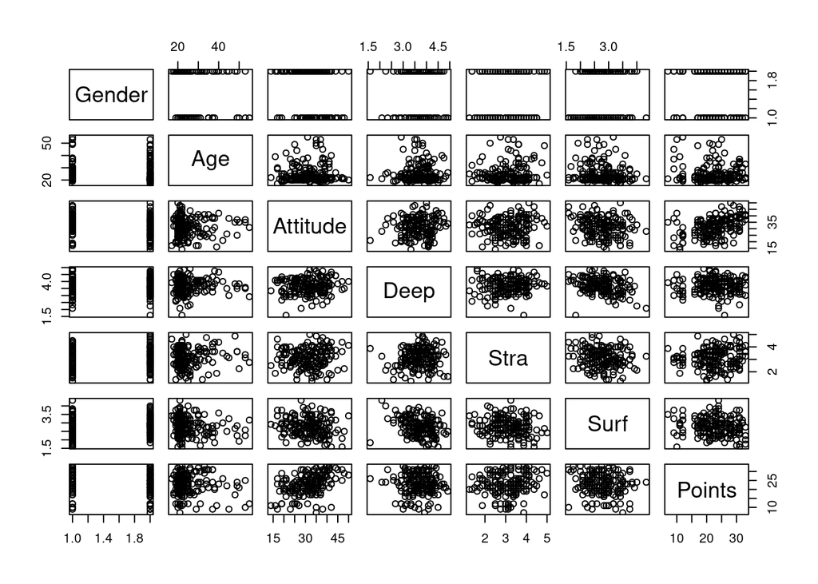

```r
pairs(learning2014)
```

Visually at least Attitude seems to have relationship with Points. To further investigate this, let’s additionally draw a correlation plot.

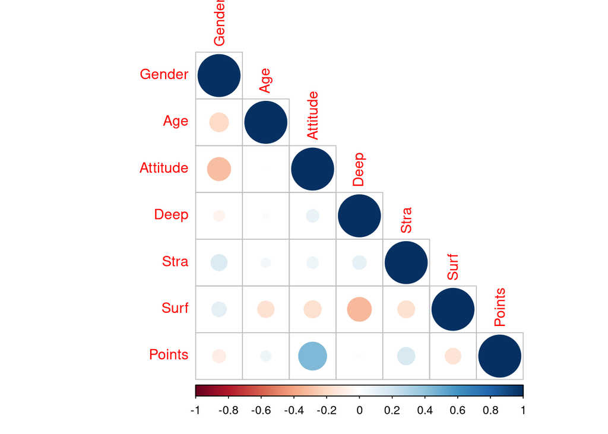

```r
library(corrplot)
corrplot(cor(learning2014, method="spearman"), type="lower")
```

Attitude clearly correlates with Points. Furthermore, Age, gender, stra, and surf all seem to have a small correlation. Given we are allowed to choose only three variables for this exercise, age and gender with attitude seem most interesting combination.

## Linear regression model

Lets try first a model with Age, Gender (basic demographic covariates) and Attitude as a third one.

```r
#library(rms)
summary(lm(Points~Age+I(as.factor(Gender))*Attitude, data=learning2014))
```

```
##
## Call:
## lm(formula = Points ~ Age + I(as.factor(Gender)) * Attitude,
##     data = learning2014)
##
## Residuals:
##      Min       1Q   Median       3Q      Max
## -17.3457  -3.3677   0.1811   3.8529  10.2281
##
## Coefficients:
##                                Estimate Std. Error t value Pr(>|t|)
## (Intercept)                    11.21591    4.18555   2.680 0.008135 **
## Age                            -0.07516    0.05379  -1.397 0.164246
## I(as.factor(Gender))2           2.84438    4.45715   0.638 0.524274
## Attitude                        0.41480    0.11115   3.732 0.000263 ***
## I(as.factor(Gender))2:Attitude -0.07583    0.13155  -0.576 0.565115
## ---
## Signif. codes:  0 '***' 0.001 '**' 0.01 '*' 0.05 '.' 0.1 ' ' 1
##
## Residual standard error: 5.326 on 161 degrees of freedom
## Multiple R-squared:  0.2034, Adjusted R-squared:  0.1836
## F-statistic: 10.28 on 4 and 161 DF,  p-value: 1.944e-07
```

Apparently age and gender have no statistical effect in the model, let’s keep only attitude.

```r
summary(lm(Points~Attitude, data=learning2014))
```

```
##
## Call:
## lm(formula = Points ~ Attitude, data = learning2014)
##
## Residuals:
##      Min       1Q   Median       3Q      Max
## -16.9763  -3.2119   0.4339   4.1534  10.6645
##
## Coefficients:
##             Estimate Std. Error t value Pr(>|t|)
## (Intercept) 11.63715    1.83035   6.358 1.95e-09 ***
## Attitude     0.35255    0.05674   6.214 4.12e-09 ***
## ---
## Signif. codes:  0 '***' 0.001 '**' 0.01 '*' 0.05 '.' 0.1 ' ' 1
##
## Residual standard error: 5.32 on 164 degrees of freedom
## Multiple R-squared:  0.1906, Adjusted R-squared:  0.1856
## F-statistic: 38.61 on 1 and 164 DF,  p-value: 4.119e-09
```

As attitude has ambiguous dimensions, let’s mean scale it (mean=0, sd=1) for easier interpretation.

```r
summary(lm(Points~I(scale(Attitude)), data=learning2014))
```

```
##
## Call:
## lm(formula = Points ~ I(scale(Attitude)), data = learning2014)
##
## Residuals:
##      Min       1Q   Median       3Q      Max
## -16.9763  -3.2119   0.4339   4.1534  10.6645
##
## Coefficients:
##                    Estimate Std. Error t value Pr(>|t|)
## (Intercept)         22.7169     0.4129  55.019  < 2e-16 ***
## I(scale(Attitude))   2.5733     0.4141   6.214 4.12e-09 ***
## ---
## Signif. codes:  0 '***' 0.001 '**' 0.01 '*' 0.05 '.' 0.1 ' ' 1
##
## Residual standard error: 5.32 on 164 degrees of freedom
## Multiple R-squared:  0.1906, Adjusted R-squared:  0.1856
## F-statistic: 38.61 on 1 and 164 DF,  p-value: 4.119e-09
```

Now we can say that Attitude is highly significant in this model (p=4e-9). It’s effect (beta) is 2.5733, which means that one standard deviation increase in Attitude increases Points by apx. 2.57.

Multiple R-squared is 0.1906 which means that Attitude alone explains 19% of variability of Points.

### Model diagnostics

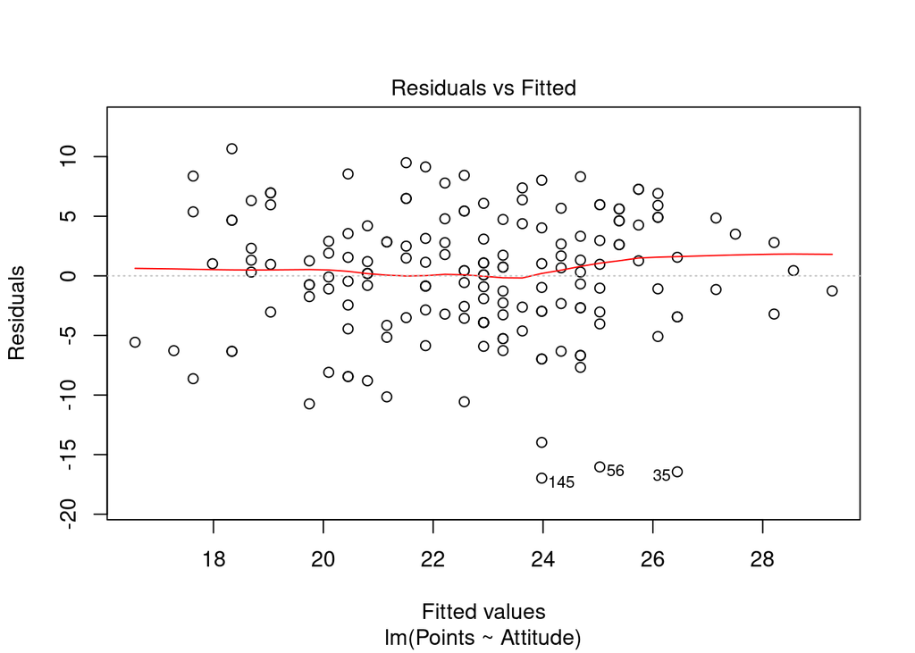

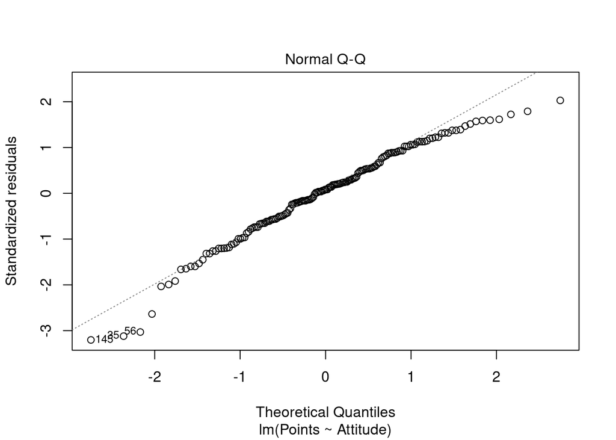

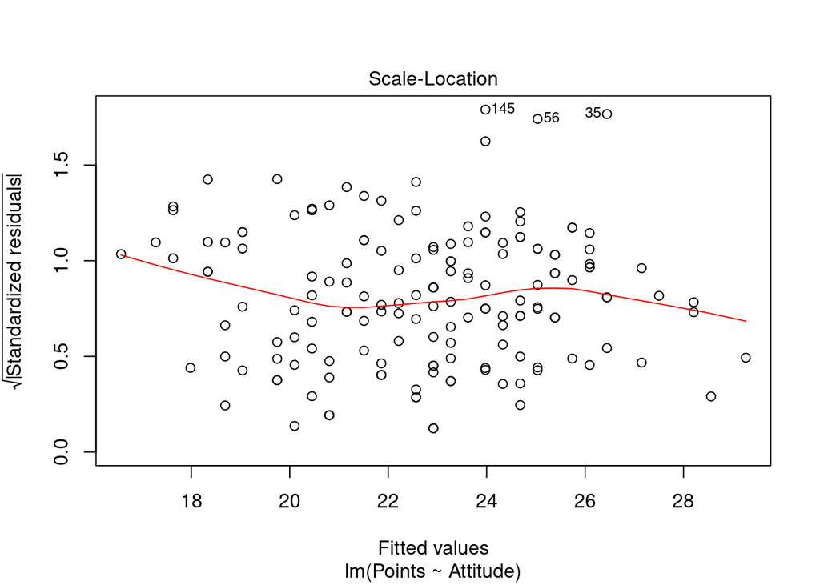

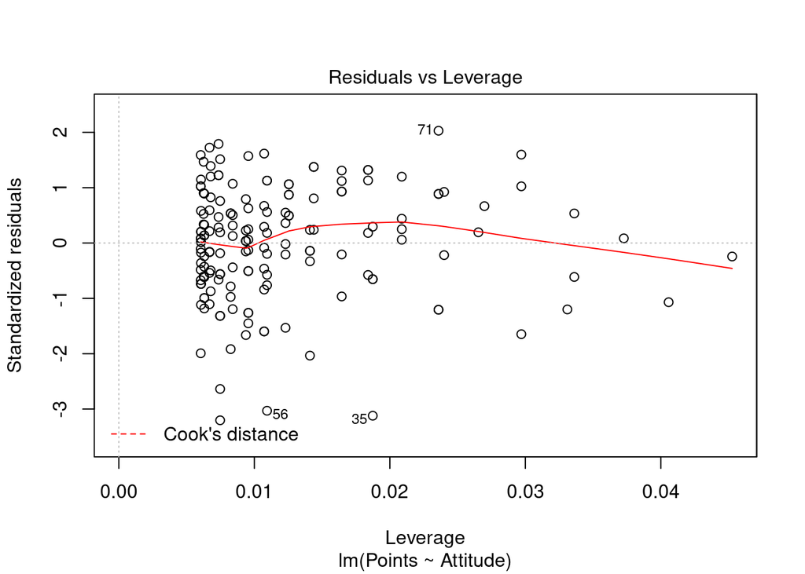

```r
plot(lm(Points~Attitude, data=learning2014))
```